Skip to content

```python
from __future__ import annotations

import matplotlib.pyplot as plt
import numpy as np
import pandas as pd

import mxlpy as mb2
from example_models import (
    get_linear_chain_2v,
)
from mxlpy import make_protocol, plot, scan
```

from __future__ import annotations import matplotlib.pyplot as plt import numpy as np import pandas as pd import mxlpy as mb2 from example_models import ( get_linear_chain_2v, ) from mxlpy import make_protocol, plot, scan

# Parameter scans

Parameter scans allow you to systematically assess the behaviour of your model dependent on the value of one or more parameters.  
*mxlpy* has routines to scan over, and easily visualise **time courses**, **protocol time courses**, and **steady states** for one or more parameters.

[figure not shown]

For this, we import the `scan` and `plot` modules from which contain the respective routines.

## Steady-state

The steady-state scan takes a `pandas.DataFrame` of parameters to be scanned as an input and returns the steady-states at the respective parameter values.

The DataFrame can take an arbitrary number of parameters and should be in the following format

| n | k1 |
| --- | --- |
| 0 | 1 |
| 1 | 1.2 |
| 2 | 1.4 |

$$ \varnothing \xrightarrow{v_1} S \xrightarrow{v_2} P \xrightarrow{v_3} \varnothing$$

```python
res = scan.steady_state(
    get_linear_chain_2v(),
    parameters=pd.DataFrame({"k1": np.linspace(1, 3, 11)}),
)

fig, (ax1, ax2) = plot.two_axes(figsize=(7, 3))
plot.lines(res.variables, ax=ax1)  # access concentrations by name
plot.lines(res.fluxes, ax=ax2)  # access fluxes by name

ax1.set(ylabel="Concentration / a.u.")
ax2.set(ylabel="Flux / a.u.")
plt.show()
```

res = scan.steady_state( get_linear_chain_2v(), parameters=pd.DataFrame({"k1": np.linspace(1, 3, 11)}), ) fig, (ax1, ax2) = plot.two_axes(figsize=(7, 3)) plot.lines(res.variables, ax=ax1) # access concentrations by name plot.lines(res.fluxes, ax=ax2) # access fluxes by name ax1.set(ylabel="Concentration / a.u.") ax2.set(ylabel="Flux / a.u.") plt.show()

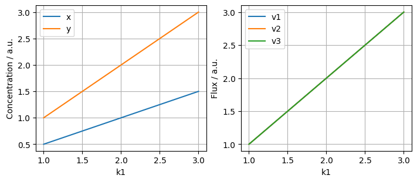

All scans return a result object, which allow multiple access patterns for convenience.

Namely, the concentrations and fluxes can be accessed by name, unpacked or combined into a single dataframe.

```python
# Access by name
_ = res.variables
_ = res.fluxes

# scan can be unpacked
concs, fluxes = res

# combine concs and fluxes as single dataframe
_ = res.results
```

# Access by name _ = res.variables _ = res.fluxes # scan can be unpacked concs, fluxes = res # combine concs and fluxes as single dataframe _ = res.results

#### Combinations

Often you want to scan over multiple parameters at the same time.  
The recommended way to do this is to use the `cartesian_product` function, which takes a `parameter_name: values` mapping and creates a `pandas.DataFrame` of their combinations from it (think nested for loop).

In the case the parameters `DataFrame` contains more than one column, the returned `pandas.DataFrame` will contain a `pandas.MultiIndex`.

```python
mb2.cartesian_product(
    {
        "k1": [1, 2],
        "k2": [3, 4],
    }
)
```

mb2.cartesian_product( { "k1": [1, 2], "k2": [3, 4], } )

|  | k1 | k2 |
| --- | --- | --- |
| 0 | 1 | 3 |
| 1 | 1 | 4 |
| 2 | 2 | 3 |
| 3 | 2 | 4 |

```python
res = scan.steady_state(
    get_linear_chain_2v(),
    parameters=mb2.cartesian_product(
        {
            "k1": np.linspace(1, 2, 3),
            "k2": np.linspace(1, 2, 4),
        }
    ),
)

res.results.head()
```

res = scan.steady_state( get_linear_chain_2v(), parameters=mb2.cartesian_product( { "k1": np.linspace(1, 2, 3), "k2": np.linspace(1, 2, 4), } ), ) res.results.head()

| k1 | k2 | x | y | v1 | v2 | v3 |
| --- | --- | --- | --- | --- | --- | --- |
| 1.0 | 1.000000 | 1.00 | 1.0 | 1.0 | 1.0 | 1.0 |
|  | 1.333333 | 0.75 | 1.0 | 1.0 | 1.0 | 1.0 |
|  | 1.666667 | 0.60 | 1.0 | 1.0 | 1.0 | 1.0 |
|  | 2.000000 | 0.50 | 1.0 | 1.0 | 1.0 | 1.0 |
| 1.5 | 1.000000 | 1.50 | 1.5 | 1.5 | 1.5 | 1.5 |

You can plot the results of a **single variable** of this scan using a heatmap

```python
plot.heatmap_from_2d_idx(res.variables, variable="x")
plt.show()
```

plot.heatmap_from_2d_idx(res.variables, variable="x") plt.show()

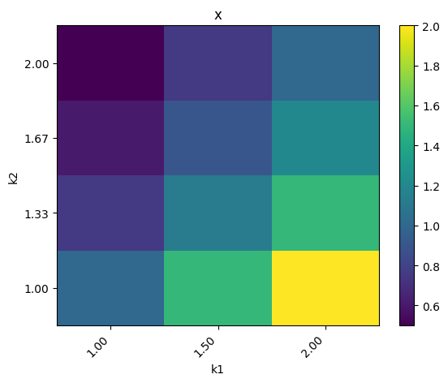

Or create heatmaps of all passed variables at once.

```python
plot.heatmaps_from_2d_idx(res.variables)
plt.show()
```

plot.heatmaps_from_2d_idx(res.variables) plt.show()

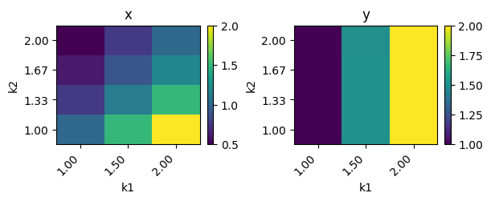

You can also combine more than two parameters, however, visualisation then becomes challenging.

```python
res = scan.steady_state(
    get_linear_chain_2v(),
    mb2.cartesian_product(
        {
            "k1": np.linspace(1, 2, 3),
            "k2": np.linspace(1, 2, 4),
            "k3": np.linspace(1, 2, 4),
        }
    ),
)
res.results.head()
```

res = scan.steady_state( get_linear_chain_2v(), mb2.cartesian_product( { "k1": np.linspace(1, 2, 3), "k2": np.linspace(1, 2, 4), "k3": np.linspace(1, 2, 4), } ), ) res.results.head()

| k1 | k2 | k3 | x | y | v1 | v2 | v3 |
| --- | --- | --- | --- | --- | --- | --- | --- |
| 1.0 | 1.000000 | 1.000000 | 1.00 | 1.00 | 1.0 | 1.0 | 1.0 |
|  |  | 1.333333 | 1.00 | 0.75 | 1.0 | 1.0 | 1.0 |
|  |  | 1.666667 | 1.00 | 0.60 | 1.0 | 1.0 | 1.0 |
|  |  | 2.000000 | 1.00 | 0.50 | 1.0 | 1.0 | 1.0 |
|  | 1.333333 | 1.000000 | 0.75 | 1.00 | 1.0 | 1.0 | 1.0 |

### Time course

You can perform a time course for each of the parameter values, resulting in a **distribution of time courses**.  
The index now also contains the time, so even for one parameter a `pandas.MultiIndex` is used.

```python
tss = scan.time_course(
    get_linear_chain_2v(),
    parameters=pd.DataFrame({"k1": np.linspace(1, 2, 11)}),
    time_points=np.linspace(0, 1, 11),
)

fig, (ax1, ax2) = plot.two_axes(figsize=(7, 4))
plot.lines_mean_std_from_2d_idx(tss.variables, ax=ax1)
plot.lines_mean_std_from_2d_idx(tss.fluxes, ax=ax2)

ax1.set(xlabel="time / a.u.", ylabel="Concentration / a.u.")
ax2.set(xlabel="time / a.u.", ylabel="Flux / a.u.")
plt.show()
```

tss = scan.time_course( get_linear_chain_2v(), parameters=pd.DataFrame({"k1": np.linspace(1, 2, 11)}), time_points=np.linspace(0, 1, 11), ) fig, (ax1, ax2) = plot.two_axes(figsize=(7, 4)) plot.lines_mean_std_from_2d_idx(tss.variables, ax=ax1) plot.lines_mean_std_from_2d_idx(tss.fluxes, ax=ax2) ax1.set(xlabel="time / a.u.", ylabel="Concentration / a.u.") ax2.set(xlabel="time / a.u.", ylabel="Flux / a.u.") plt.show()

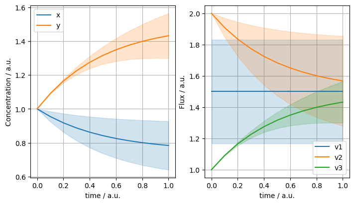

Again, this works for an arbitray number of parameters.

```python
tss = scan.time_course(
    get_linear_chain_2v(),
    parameters=mb2.cartesian_product(
        {
            "k1": np.linspace(1, 2, 11),
            "k2": np.linspace(1, 2, 4),
        }
    ),
    time_points=np.linspace(0, 1, 11),
)


fig, (ax1, ax2) = plot.two_axes(figsize=(7, 4))
plot.lines_mean_std_from_2d_idx(tss.variables, ax=ax1)
plot.lines_mean_std_from_2d_idx(tss.fluxes, ax=ax2)
ax1.set(xlabel="time / a.u.", ylabel="Concentration / a.u.")
ax2.set(xlabel="time / a.u.", ylabel="Flux / a.u.")
plt.show()
```

tss = scan.time_course( get_linear_chain_2v(), parameters=mb2.cartesian_product( { "k1": np.linspace(1, 2, 11), "k2": np.linspace(1, 2, 4), } ), time_points=np.linspace(0, 1, 11), ) fig, (ax1, ax2) = plot.two_axes(figsize=(7, 4)) plot.lines_mean_std_from_2d_idx(tss.variables, ax=ax1) plot.lines_mean_std_from_2d_idx(tss.fluxes, ax=ax2) ax1.set(xlabel="time / a.u.", ylabel="Concentration / a.u.") ax2.set(xlabel="time / a.u.", ylabel="Flux / a.u.") plt.show()

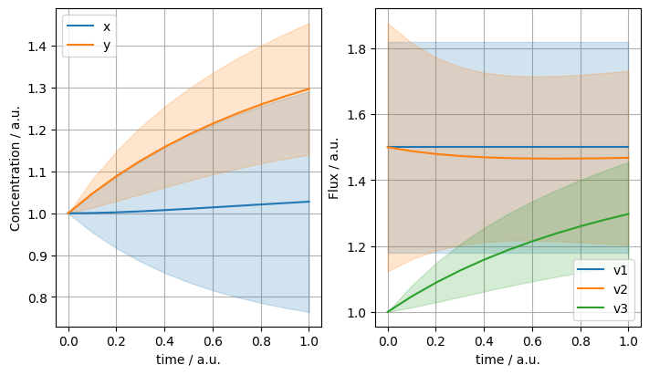

The scan object returned has a `pandas.MultiIndex` of `n x time`, where `n` is an index that references parameter combinations.  
You can access the referenced parameters using `.parameters`

```python
tss.parameters.head()
```

tss.parameters.head()

|  | k1 | k2 |
| --- | --- | --- |
| 0 | 1.0 | 1.000000 |
| 1 | 1.0 | 1.333333 |
| 2 | 1.0 | 1.666667 |
| 3 | 1.0 | 2.000000 |
| 4 | 1.1 | 1.000000 |

You can also easily access common aggregates like `mean` and `standard deviation (std)` using `get_agg_per_time`.

```python
tss.get_agg_per_time("std").head()
```

tss.get_agg_per_time("std").head()

| time | x | y | v1 | v2 | v3 |
| --- | --- | --- | --- | --- | --- |
| 0.0 | 0.000000 | 0.000000 | 0.319884 | 0.376987 | 0.000000 |
| 0.1 | 0.045932 | 0.033365 | 0.319884 | 0.328164 | 0.033365 |
| 0.2 | 0.085571 | 0.059438 | 0.319884 | 0.293370 | 0.059438 |
| 0.3 | 0.119871 | 0.079991 | 0.319884 | 0.270384 | 0.079991 |
| 0.4 | 0.149628 | 0.096455 | 0.319884 | 0.256845 | 0.096455 |

### Protocol

The same can be done for protocols.

```python
res = scan.time_course_over_protocol(
    get_linear_chain_2v(),
    parameters=pd.DataFrame({"k2": np.linspace(1, 2, 11)}),
    protocol=make_protocol(
        [
            (1, {"k1": 1}),
            (2, {"k1": 2}),
            (3, {"k1": 1}),
        ]
    ),
)

fig, (ax1, ax2) = plot.two_axes(figsize=(7, 4))
plot.lines_mean_std_from_2d_idx(res.variables, ax=ax1)
plot.lines_mean_std_from_2d_idx(res.fluxes, ax=ax2)
ax1.set(xlabel="time / a.u.", ylabel="Concentration / a.u.")
ax2.set(xlabel="time / a.u.", ylabel="Flux / a.u.")

for ax in (ax1, ax2):
    plot.shade_protocol(res.protocol["k1"], ax=ax, alpha=0.2)
plt.show()
```

res = scan.time_course_over_protocol( get_linear_chain_2v(), parameters=pd.DataFrame({"k2": np.linspace(1, 2, 11)}), protocol=make_protocol( [ (1, {"k1": 1}), (2, {"k1": 2}), (3, {"k1": 1}), ] ), ) fig, (ax1, ax2) = plot.two_axes(figsize=(7, 4)) plot.lines_mean_std_from_2d_idx(res.variables, ax=ax1) plot.lines_mean_std_from_2d_idx(res.fluxes, ax=ax2) ax1.set(xlabel="time / a.u.", ylabel="Concentration / a.u.") ax2.set(xlabel="time / a.u.", ylabel="Flux / a.u.") for ax in (ax1, ax2): plot.shade_protocol(res.protocol["k1"], ax=ax, alpha=0.2) plt.show()

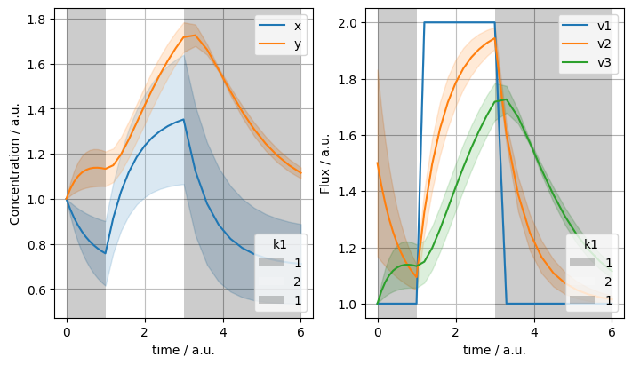

## First finish line

With that you now know most of what you will need from a day-to-day basis about parameter scans in mxlpy.  
Congratulations!

```python
import pickle
from pathlib import Path
from typing import TYPE_CHECKING, Any

from mxlpy.parallel import Cache, parallelise

if TYPE_CHECKING:
    from collections.abc import Hashable
```

import pickle from pathlib import Path from typing import TYPE_CHECKING, Any from mxlpy.parallel import Cache, parallelise if TYPE_CHECKING: from collections.abc import Hashable

## Parallel execution

By default, all scans are executed in parallel.  
To do this, they internally use the `parallelise` function defined by `mxlpy`.

> Tip: You can also use this function for other analyses as it is not specific to any `mxlpy` constructs.

The `parallelise` takes a function of type `T` and an iterable of a `key: T` pair.  
The key is used to construct a dictionary of results and for caching (see below).

```python
def square(x: float) -> float:
    return x**2


output = parallelise(square, [("a", 2), ("b", 3), ("c", 4)])
output
```

def square(x: float) -> float: return x**2 output = parallelise(square, [("a", 2), ("b", 3), ("c", 4)]) output

```
{'a': 4, 'b': 9, 'c': 16}
```

## Caching

In case the simulations take a significant amount of time to run, it makes sense to cache the results on disk.  
You can do that by adding a `cache` to the `parallelise` function (and thus to all `scan` functions as well).

```
parallelise(...,  cache=Cache())
```

The first time the scan is run, the calculations are done, every subsequent time the results are loaded.

```python
output = parallelise(
    square,
    [("a", 2), ("b", 3), ("c", 4)],
    cache=Cache(),
)
```

output = parallelise( square, [("a", 2), ("b", 3), ("c", 4)], cache=Cache(), )

To avoid overwriting cache results by different analyses we recommend saving each of them in a respective folder.

```python
_ = Cache(tmp_dir=Path(".cache") / "analysis-name")
```

_ = Cache(tmp_dir=Path(".cache") / "analysis-name")

By default the `key` of `parallelise` is used to create a pickle file called `{k}.p`.  
You can customise this behaviour by changing the `name_fn`, `load_fn` and `save_fn` arguments respectively.

```python
def _pickle_name(k: Hashable) -> str:
    return f"{k}.p"


def _pickle_load(file: Path) -> Any:
    with file.open("rb") as fp:
        return pickle.load(fp)


def _pickle_save(file: Path, data: Any) -> None:
    with file.open("wb") as fp:
        pickle.dump(data, fp)


_ = Cache(
    name_fn=_pickle_name,
    load_fn=_pickle_load,
    save_fn=_pickle_save,
)
```

def _pickle_name(k: Hashable) -> str: return f"{k}.p" def _pickle_load(file: Path) -> Any: with file.open("rb") as fp: return pickle.load(fp) def _pickle_save(file: Path, data: Any) -> None: with file.open("wb") as fp: pickle.dump(data, fp) _ = Cache( name_fn=_pickle_name, load_fn=_pickle_load, save_fn=_pickle_save, )